# Barbell lift analysis

KHYS / kshu

1 August 2018

# Data preparation and transformation

The preliminary step of this analysis is to conduct some exploratory data analysis. As the first three columns to the right of `X` and `user_name` were timestamps, the first question that sprang was whether a time series analysis would be germane. As there are only 2 unique dates, the answer to that question is no.

Next, the issue of missing observations among the numeric predictors was examined using the `method=bagImpute` in the `preProcess` function of the `caret` library. The “imputed” data frame, stored in `ssTrImputed` had the exact same numeric predictor indices result in an `NA` as those of the pre-imputed data frame, `ssPmlTr`. This is not surprising, since between 97.9% and 100% of the observations were missing whenever a predictor had any `NA` values. Thus, the author decided to proceed in the analysis by removing all categorical/text predictors (`X`, `user_name`, `raw_timestamp_part_1`, `raw_timestamp_part_2`, and `cvtd_timestamp`) from the predictor data frame.

# Cross-validation and model construction

Explicit cross-validation was performed only twice, once using the `rknn.cv` function in the `rknn` package to obtain the “sub-train” predictions. The second time was to confirm, using the `rfcv` function in the `randomForest` package, that the predictive accuracy and kappa score were best when all 26 variables of the PCA-reduced training set were used. Otherwise, cross-validation on resampling was performed using `trainControl` in `caret` by setting `method` to equal `cv`. As this is a classification problem, `classProbs` was also set to `TRUE`.

```r
trCtrl <- trainControl(method = "cv", savePred=T, classProbs=T)
idxSS<-createDataPartition(y=pmlTr$classe, p=0.8, list=FALSE)
dfSample<-dfNonmissingTr[idxSS,]

samplePC<-predict(pcaPreProc, dfSample)
classesSample<-pmlTr$classe[idxSS]
oosPC<-processTest(pmlTr[-idxSS,])
classesOOS<-pmlTr$classe[-idxSS]

# bagged KNN; see rknn package #
# pcaFitRKNN<-rknn(data=samplePC, newdata=oosPC, y=classesSample)
rknnSample<-rknn.cv(data=samplePC, y=classesSample)
confusionMatrix(rknnSample$pred, classesSample)
```

```
## Confusion Matrix and Statistics
##
##           Reference
## Prediction    A    B    C    D    E
##          A 4444   28    4    2    0
##          B    7 2979   29    5    5
##          C    7   28 2691   65    7
##          D    3    1   12 2496    8
##          E    3    2    2    5 2866
##
## Overall Statistics
##
##                Accuracy : 0.9858
##                  95% CI : (0.9838, 0.9876)
##     No Information Rate : 0.2843
##     P-Value [Acc > NIR] : < 2.2e-16
##
##                   Kappa : 0.982
##  Mcnemar's Test P-Value : 2.866e-09
##
## Statistics by Class:
##
##                      Class: A Class: B Class: C Class: D Class: E
## Sensitivity            0.9955   0.9806   0.9828   0.9701   0.9931
## Specificity            0.9970   0.9964   0.9917   0.9982   0.9991
## Pos Pred Value         0.9924   0.9848   0.9618   0.9905   0.9958
## Neg Pred Value         0.9982   0.9953   0.9964   0.9942   0.9984
## Prevalence             0.2843   0.1935   0.1744   0.1639   0.1838
## Detection Rate         0.2831   0.1898   0.1714   0.1590   0.1826
## Detection Prevalence   0.2852   0.1927   0.1782   0.1605   0.1833
## Balanced Accuracy      0.9962   0.9885   0.9873   0.9841   0.9961
```

```r
# Random forest #
pcaRFCV<-rfcv(samplePC, classesSample)
pcaRFCV$error.cv
```

```
##         26         13          6          3          1
## 0.02681699 0.04681827 0.11446589 0.35632843 0.74030193
```

```r
# Random Forest with built-in CV via trControl argument #
## with actual model
pcaRF<-train(x=samplePC, y=classesSample, method="rf", trControl=trCtrl)
rfOptimumMtry<-pcaRF$results$mtry[which.max(pcaRF$results$Accuracy)]
predPcaRF<-pcaRF$pred %>% filter(mtry==rfOptimumMtry)
with(predPcaRF, confusionMatrix(pred, obs))
```

```
## Confusion Matrix and Statistics
##
##           Reference
## Prediction    A    B    C    D    E
##          A 4423   33    8    4    0
##          B   10 2950   43    2    5
##          C   19   48 2663  106   12
##          D    9    0   22 2457   15
##          E    3    7    2    4 2854
##
## Overall Statistics
##
##                Accuracy : 0.9776
##                  95% CI : (0.9751, 0.9798)
##     No Information Rate : 0.2843
##     P-Value [Acc > NIR] : < 2.2e-16
##
##                   Kappa : 0.9716
##  Mcnemar's Test P-Value : 1.389e-15
##
## Statistics by Class:
##
##                      Class: A Class: B Class: C Class: D Class: E
## Sensitivity            0.9908   0.9710   0.9726   0.9549   0.9889
## Specificity            0.9960   0.9953   0.9857   0.9965   0.9988
## Pos Pred Value         0.9899   0.9801   0.9350   0.9816   0.9944
## Neg Pred Value         0.9963   0.9931   0.9942   0.9912   0.9975
## Prevalence             0.2843   0.1935   0.1744   0.1639   0.1838
## Detection Rate         0.2817   0.1879   0.1696   0.1565   0.1818
## Detection Prevalence   0.2846   0.1917   0.1814   0.1594   0.1828
## Balanced Accuracy      0.9934   0.9831   0.9792   0.9757   0.9938
```

```r
## LDA ##
pcaFitLDA<-train(x=samplePC, y=classesSample, method="lda",
                 trControl = trCtrl)
pcaFitLDA
```

```
## Linear Discriminant Analysis
##
## 15699 samples
##    26 predictor
##     5 classes: 'A', 'B', 'C', 'D', 'E'
##
## No pre-processing
## Resampling: Cross-Validated (10 fold)
## Summary of sample sizes: 14128, 14128, 14130, 14130, 14129, 14130, ...
## Resampling results:
##
##   Accuracy   Kappa
##   0.5286319  0.403096
```

```r
## SVM ##
# pcaFitSVM_lin<-train(x=samplePC, y=classesSample, method="svmLinear",
#                      trControl = trCtrl) # fails on Linear and Poly
pcaFitSVM_auto<-svm(x=samplePC, y=classesSample, cross=10, probability=T)

print("Confusion matrix of radial SVM on training set:")
```

```
## [1] "Confusion matrix of radial SVM on training set:"
```

```r
confusionMatrix(pcaFitSVM_auto$fitted, classesSample)
```

```
## Confusion Matrix and Statistics
##
##           Reference
## Prediction    A    B    C    D    E
##          A 4427  132    9    5    6
##          B   22 2811   84    8   14
##          C   12   87 2574  222   43
##          D    3    5   69 2333   73
##          E    0    3    2    5 2750
##
## Overall Statistics
##
##                Accuracy : 0.9488
##                  95% CI : (0.9452, 0.9522)
##     No Information Rate : 0.2843
##     P-Value [Acc > NIR] : < 2.2e-16
##
##                   Kappa : 0.9352
##  Mcnemar's Test P-Value : < 2.2e-16
##
## Statistics by Class:
##
##                      Class: A Class: B Class: C Class: D Class: E
## Sensitivity            0.9917   0.9253   0.9401   0.9067   0.9529
## Specificity            0.9865   0.9899   0.9719   0.9886   0.9992
## Pos Pred Value         0.9668   0.9564   0.8761   0.9396   0.9964
## Neg Pred Value         0.9967   0.9822   0.9871   0.9818   0.9895
## Prevalence             0.2843   0.1935   0.1744   0.1639   0.1838
## Detection Rate         0.2820   0.1791   0.1640   0.1486   0.1752
## Detection Prevalence   0.2917   0.1872   0.1871   0.1582   0.1758
## Balanced Accuracy      0.9891   0.9576   0.9560   0.9476   0.9760
```

As the “sub-train” set accuracy from LDA stood at 0.5286, well below the next-“worst” performer of SVM with a radial kernel, at 0.9488, LDA was removed from consideration for any ensembling. The ensembling was a stacking of the three base models using gradient boosting.

```r
predPcaRF<-predPcaRF[order(predPcaRF$rowIndex),]
predPcaRKNN<-rknnSample$pred

dfEnsemble<-data.frame(rf=predPcaRF$pred,
                       rknn=predPcaRKNN,
                       svmRad=pcaFitSVM_auto$fitted)
gbmGarbage<-capture.output(
  gbmPCA<-train(dfEnsemble, classesSample, method="gbm",
                trControl = trCtrl))
rm(gbmGarbage)
gbmPCA
```

```
## Stochastic Gradient Boosting
##
## 15699 samples
##     3 predictor
##     5 classes: 'A', 'B', 'C', 'D', 'E'
##
## No pre-processing
## Resampling: Cross-Validated (10 fold)
## Summary of sample sizes: 14129, 14130, 14130, 14131, 14128, 14130, ...
## Resampling results across tuning parameters:
##
##   interaction.depth  n.trees  Accuracy   Kappa
##   1                   50      0.9854135  0.9815485
##   1                  100      0.9859231  0.9821938
##   1                  150      0.9858597  0.9821133
##   2                   50      0.9857321  0.9819520
##   2                  100      0.9856045  0.9817903
##   2                  150      0.9854771  0.9816287
##   3                   50      0.9858592  0.9821130
##   3                  100      0.9857954  0.9820322
##   3                  150      0.9856044  0.9817902
##
## Tuning parameter 'shrinkage' was held constant at a value of 0.1
##
## Tuning parameter 'n.minobsinnode' was held constant at a value of 10
## Accuracy was used to select the optimal model using the largest value.
## The final values used for the model were n.trees = 100,
##  interaction.depth = 1, shrinkage = 0.1 and n.minobsinnode = 10.
```

```r
bGBMimproved<-max(gbmPCA$results$Accuracy) >
  max(c(max(pcaRF$results$Accuracy),
        sum(predPcaRKNN==classesSample) / length(idxSS),
        sum(pcaFitSVM_auto$fitted==classesSample) / length(idxSS)))
```

```r
if(bGBMimproved)
  with(gbmPreds, confusionMatrix(pred, obs))
```

```
## Confusion Matrix and Statistics
##
##           Reference
## Prediction    A    B    C    D    E
##          A 4444   26    2    1    0
##          B   12 2974   20    2    5
##          C    5   34 2694   65    6
##          D    2    0   20 2497    6
##          E    1    4    2    8 2869
##
## Overall Statistics
##
##                Accuracy : 0.9859
##                  95% CI : (0.984, 0.9877)
##     No Information Rate : 0.2843
##     P-Value [Acc > NIR] : < 2.2e-16
##
##                   Kappa : 0.9822
##  Mcnemar's Test P-Value : 1.971e-05
##
## Statistics by Class:
##
##                      Class: A Class: B Class: C Class: D Class: E
## Sensitivity            0.9955   0.9789   0.9839   0.9705   0.9941
## Specificity            0.9974   0.9969   0.9915   0.9979   0.9988
## Pos Pred Value         0.9935   0.9871   0.9608   0.9889   0.9948
## Neg Pred Value         0.9982   0.9950   0.9966   0.9942   0.9987
## Prevalence             0.2843   0.1935   0.1744   0.1639   0.1838
## Detection Rate         0.2831   0.1894   0.1716   0.1591   0.1828
## Detection Prevalence   0.2849   0.1919   0.1786   0.1608   0.1837
## Balanced Accuracy      0.9965   0.9879   0.9877   0.9842   0.9965
```

# Visuals

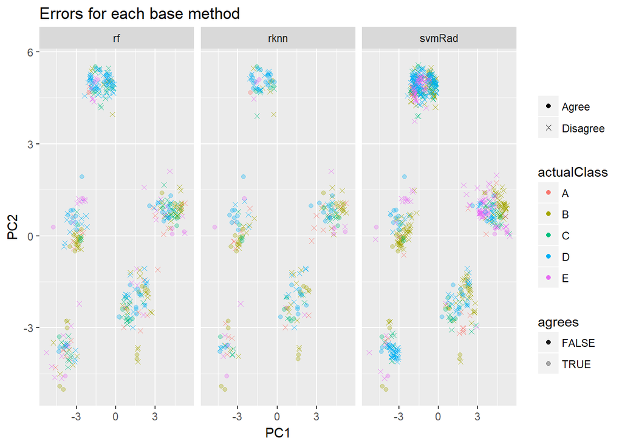

```r
ggplot(errorMelt) +
  geom_point(aes(x=PC1, y=PC2,
                 colour=actualClass, alpha=agrees,
                 shape=ifelse(agrees, "Agree", "Disagree"))) +
  facet_grid(.~method) +
  scale_alpha_discrete(range=c(0.9,0.3)) +
  scale_shape_manual(name="", values=c(Disagree=4,Agree=19)) +
  ggtitle("Errors for each base method")
```

Now, a look at the classes predicted by `RKNN` and graphed by the first two principal components; `alpha` is set to $0.1$ to highlight density of classes.

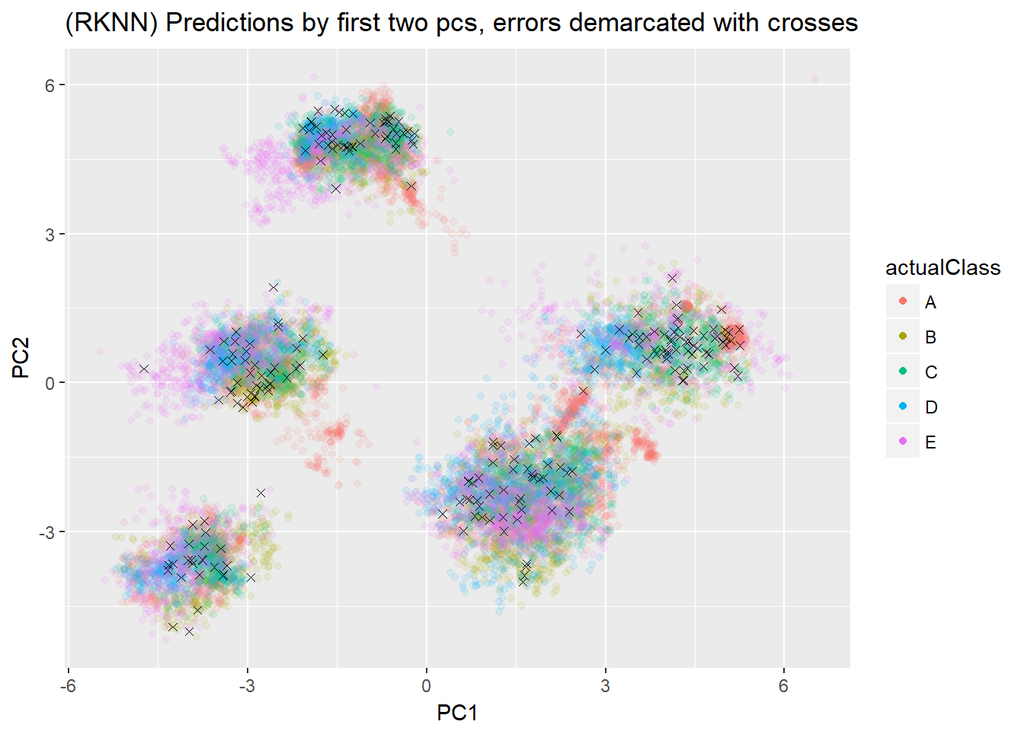

```r
ggplot(dfPredsTrio[-idxErrorRKNN,]) +
  geom_point(aes(x=PC1, y=PC2, colour=actualClass), alpha=0.1) +
  geom_point(data=dfPredsTrio[idxErrorRKNN,], aes(x=PC1, y=PC2),
             shape=4) +
  # force legend to have default transparency level
  guides(colour = guide_legend(override.aes=list(alpha=1))) +
  ggtitle(paste("(RKNN) Predictions by first two pcs,",
                " errors demarcated with crosses", sep=""))
```

The next plot of `RKNN` predictions further demonstrates the gaps in specificity by actual class. Again the region defined by $\text{PC}_1 \in [-3,0] \land \text{PC}_2\in[3.75,6]$ has a preponderance of failure to predict class `D`, but this plot demonstrates the significant overlap in that region with classes `B` and `C` as well as the remaining two classes to a lesser degree.

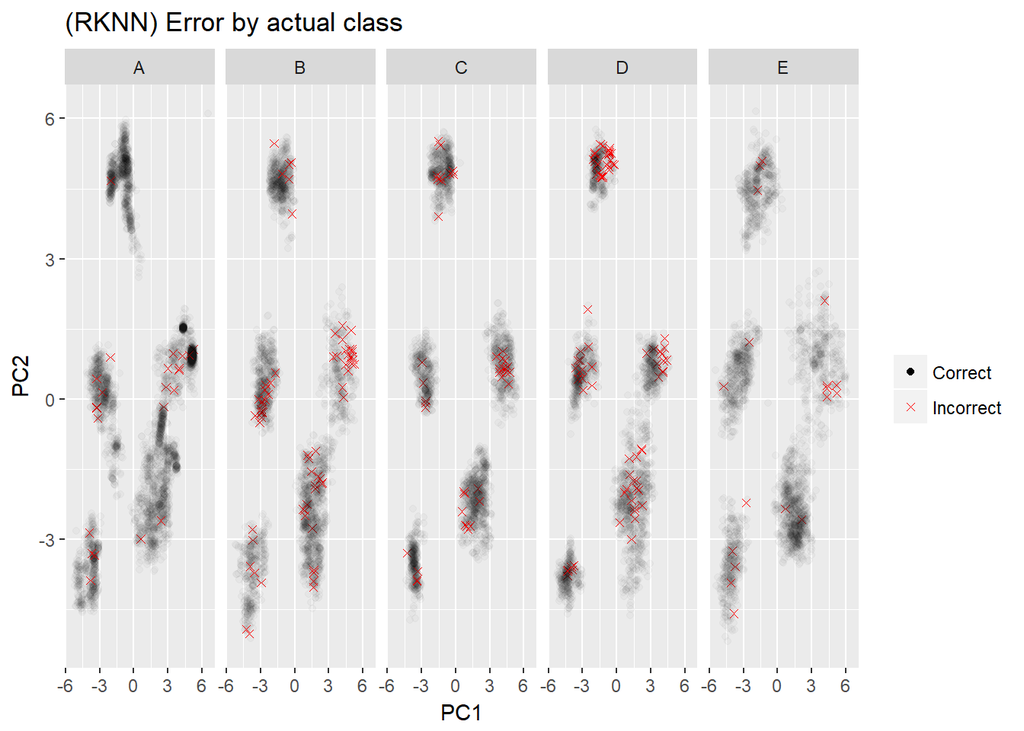

```r
ggplot(dfRKNN) +
  facet_grid(.~actualClass) +
  geom_point(aes(x=PC1, y=PC2, alpha=isError,
                 color=ifelse(isError,
                              "Incorrect",
                              "Correct"),
                 shape=ifelse(isError,
                              "Incorrect",
                              "Correct"))) +
  scale_colour_manual(name="", values=c(Incorrect="Red",Correct="Black")) +
  scale_alpha_discrete(range=c(0.025,1), guide=FALSE) + # remove legend
  scale_shape_manual(name="", values=c(Incorrect=4,Correct=19)) +
  ggtitle("(RKNN) Error by actual class")
```

```r
predictTest<-function(df, testLabels) {
  # df is a pca-preprocessed data frame
  stopifnot(ncol(df) == ncol(samplePC))
  stopifnot(all(levels(testLabels) == levels(classesSample)))
  fitRKNN<-rknn(data=samplePC, newdata=df, y=classesSample)
  # fitRKNN<-pcaFitRKNN
  testRF<-predict(pcaRF, df)
  testSVM<-predict(pcaFitSVM_auto, df)
  testEnsemble<-data.frame(rf=testRF,
                           rknn=fitRKNN$pred,
                           svmRad=testSVM)
  testGBM<-predict(gbmPCA, testEnsemble)
  return(testGBM)
}
oosGBM<-predictTest(oosPC, classesOOS)
```